# Is Trump more negative or positive over tweets?

Text Analysis Project Showcase · November 3, 2026

Author

Johnny Amato · POLS 4130 · Fall 2026

## Question

Is Trump more positive or negative over twitter in mid 2020?

### Data

I used the Kaggle dataset “Trump’s Legacy” (zusmani), a collection of tweets from @realDonaldTrump. The dataset description says it was built from Twitter and Trump Twitter Archive data. The date range is May 1, 2020 to September 9, 2020. The raw Kaggle file contains 56,571 rows(tweets) however, the window that I am looking at contains 4,708 rows(tweets).

### Methods

**Sentiment:** I used the AFINN lexicon (Finn Årup Nielsen), which assigns words an integer valence from -5 (most negative) to +5 (most positive). Each tweet was tokenized into words, and words found in AFINN were matched to their values. Within each tweet, I summed the matched values to get one document score. I excluded “endorsement,” “complete,” “total,” and “trump” before scoring, because they come from a repeated endorsement template or a name rather than actual expressed sentiment by Trump. I then averaged the document scores by group of targets: “China”, “Biden”, “Media”, “Democrats”.

**Topics:** 1,856 of 1,899 cleaned tweets (97.7%) had at least one word remaining after preprocessing and were included in the topic model. The model used 5,154 unique words. I compared k = 3, 4, 5 and 6. At lower values, the same words appeared in several topics and the topics overlapped. At k = 6, each topic had a distinct set of words, so I chose k = 6. I then checked each topic’s top words against the three tweets with the highest topic weight for that topic. Topics 4, 5 and 6 matched their top words.

## Sentiment finding

Coverage: 1,634 of 1,899 cleaned tweets (86.0%) contained at least one AFINN word and received a score. The other 265 tweets had no matched words and were left out of the sentiment results. Of the 1,634 scored tweets, about 63% were positive, 32% were negative, and 5% were neutral. Positive words were more common than negative ones overall. The caveat is this counts dictionary words only, so it can’t detect things like sarcasm or negation, and certain words in promotional tweets may push the positive share up.

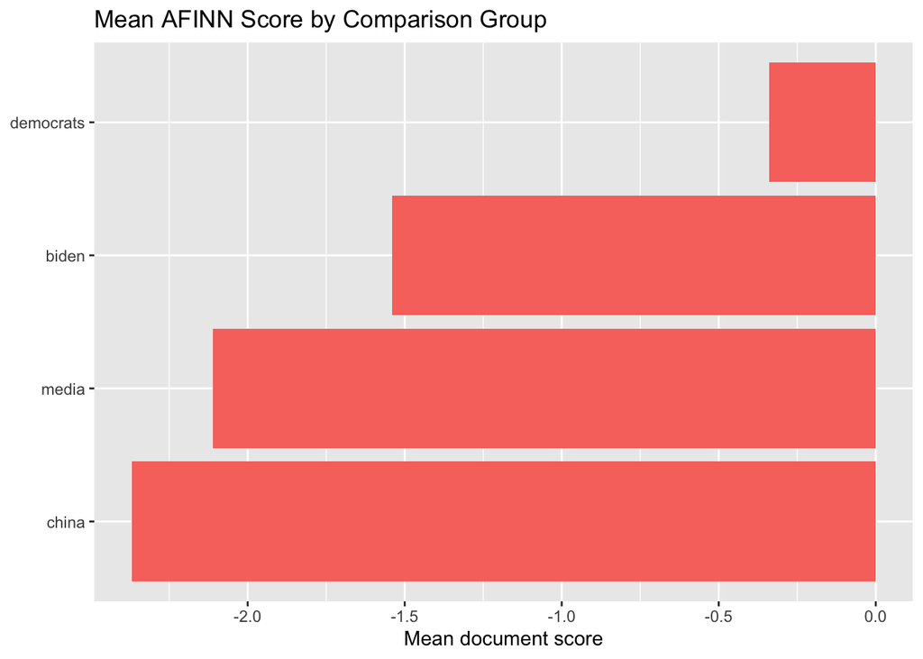

## Topic finding

Candidate endorsements formed their own distinct topic (Topic 6). Its top words and its highest-weight tweets, such as certain endorsements matched clearly so this repeated template stood apart from the other themes.

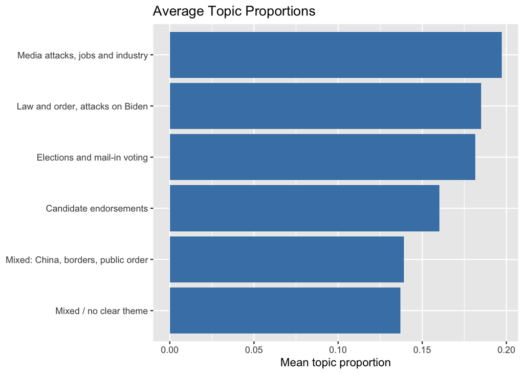

## Check the original texts

**Sentiment and Topics:** Congratulations to @RonnyJackson4TX on a big win against a tough and really good opponent…” (tweet_id 1458, July 15, 2020). This tweet scored 23 because AFINN matched eight positive words: congratulations (2), big (1), win (4), good (3), fantastic (4), wonderful (4), great (3) and proud (2). The score captures the wording well, because the tweet is a celebratory congratulation and the dictionary words reflect that. One caution is that scores are summed, so a tweet with many positive words scores very high. The 23 shows a lot of positive wording, not that this tweet is more positive in tone than a shorter one with the same message.

### Limits

**Sentiment:** The dictionary misses who sentiment is aimed at. In the tweet “Sean Parnell is an American Hero. Connor Lamb has proven to be an American fraud, and a puppet for Crazy…” (tweet_id 519), AFINN matched “hero” (+2), “fraud” (-4), “crazy” (-2) and “kill” (-3), for a net score of -7 after excluding “endorsement.” The tweet is an endorsement of one candidate, yet it scores negative because the attack on his opponent contains stronger negative words. The single net score hides that the praise and the attack are aimed at different people.

**Topics:** Topic 1’s top words (china, country, testing, world, virus) suggested a China and COVID theme, but its highest-weight tweets were mixed. One was about arrests at a D.C. vandalism protest, one about the China travel ban, and one about funding for a Michigan bridge and port of entry. Only the China tweet matched the label, so I labeled the topic as mixed (“China, borders, public order”) and treat it as approximate. Topic 2 was similar: its top tweets included a Persian-language post about Iran, a tweet about painting Fifth Avenue, and one honoring Native American soldiers, with no clear shared theme.

### Answer to the question

Originally, I thought the data showed that Trump was generally more positive over social media than negative. After working through more of this project, I am not so sure of that.

Nielsen, F. Å. (2011). A new ANEW: Evaluation of a word list for sentiment analysis in microblogs. Proceedings of the ESWC2011 Workshop on “Making Sense of Microposts.” https://arxiv.org/abs/1103.2903. The AFINN lexicon was accessed through the tidytext R package (get_sentiments(“afinn”)).